# Migration

# 1 Description of DataSchema variable

The description of harmonised variable is the following:

- Short name: `migration`
- Variable label: `If the participant was born in a different country where he/she lives now`
- Variable description: `If the participant was born in a different country where he/she lives now`
- Domain: `Socio-demographic and economic characteristics`
- Value type: `Categorical`
- Category coding:

| **Code** | **Category Label** |
| --- | --- |
| 0 | no migrant |
| 1 | migrant |

- Category missings:

| **Code** | **Category Label** |
| --- | --- |
| 991 | CAPI/interviewer error |
| 992 | Impute |
| 993 | Disable to measure |
| 994 | Not attempt/not done |
| 995 | Does not answer |
| 996 | Not applicable |
| 997 | Refuse |
| 998 | Do not know |
| 999 | Missing |

# 2 Data process

## 2.1 England

### 2.1.1 Wave 1

#### 2.1.1.1 Study-specific variable description

| **Name** | `fqcbthr` | `countrr` | `pobr` |
| --- | --- | --- | --- |
| **Label** | `ELSA Country of birth collapsed into UK and elsewhere to avoid disclosure` | `HSE Country of birth collapsed into UK and elsewhere to avoid disclosure` | `HSE Country of birth collapsed into UK and elsewhere to avoid disclosure` |
| **Table name** | `wave_1_core_data_v3` | `wave_0_1999_data_prulaia2` | `ELSA.wave_0_1998_data` |
| **Categories** | `1 = UK` `2 = Elsewhere outside of UK` | `1 = UK` `2 = Elsewhere outside of UK` | `1 = UK` `2 = Elsewhere outside of UK` |
| **Missings** | `-1 = Not applicable` `-8 = Don't Know` `-9 = Refusal` | `-1 = Not applicable` `-8 = Don't Know` `-9 = Refusal` | `-1 = Not applicable` `-8 = Don't Know` `-9 = Refusal` |
| **Description** |  |  |  |

We creared a variable `mig_w0` with the information of `pobr` and `countrr` because they ware complementary.

fqcbthr

| Sample size | Missing values |
| --- | --- |
| 12099 | 7316 |

Category

|  | 1 | 2 |
| --- | --- | --- |
| Frequency | 4430.00 | 353.00 |
| Percentage | 36.61 | 2.92 |

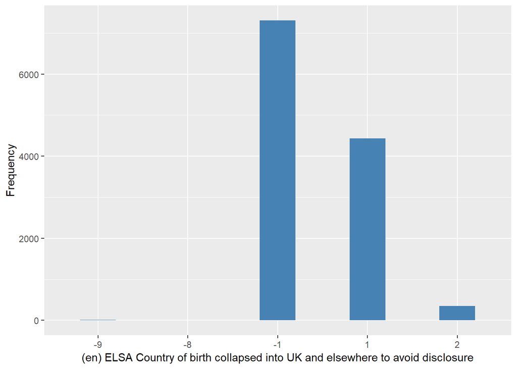

| Sample size | Missing values |
| --- | --- |
| 12099 | 4825 |

Category

|  | 1 | 2 |
| --- | --- | --- |
| Frequency | 6762.00 | 512.00 |
| Percentage | 55.89 | 4.23 |

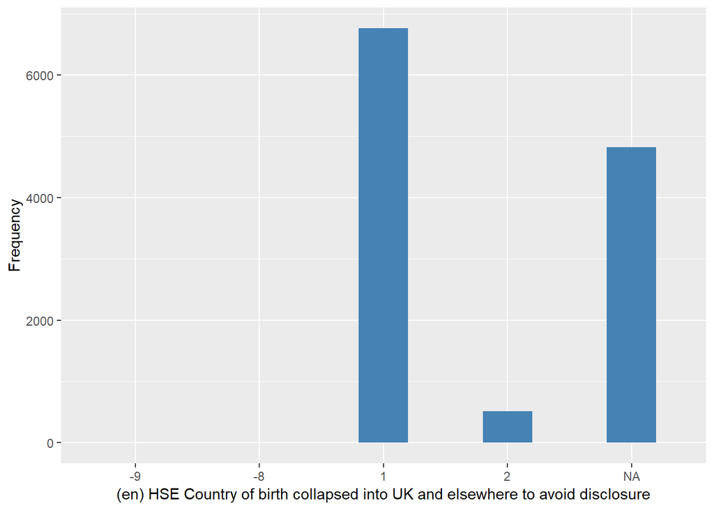

#### 2.1.1.2 Harmonisation algorithm

To compute `migration` from the study-specific variable it has to be recoded `fqcbthr` as follows:

- `1 into 0`
- `2 into 1`
- `-9 into 997`
- `-8 into 998`
- `-1 into 996`

The missing values are going to be completed with the information of the last wave.

**R script:**

```r
ELSA_w1$mig_w0 <- car::recode(ELSA_w1$mig_w0, "1 = 0; 2 = 1; -1 = 996; -9 = 997; -8 = 998; NA=999 ")

ELSA_ds_w1 <- tibble(id = ELSA_w1$id)
ELSA_ds_w1$migration <- car::recode(ELSA_w1$fqcbthr, "1 = 0; 2 = 1; -1 = 996; -9 = 997; -8 = 998 ")
ELSA_ds_w1$migration[(ELSA_ds_w1$migration %in% c(996, 997, 998, 999))] <- ELSA_w1$mig_w0[(ELSA_ds_w1$migration %in%
    c(996, 997, 998, 999))]
```

#### 2.1.1.3 Statistical description of the new harmonised variable

If the participant was born in a different country where he/she lives now

| Sample size | Missing values |
| --- | --- |
| 12099 | 82 |

Category

|  | 0 | 1 |
| --- | --- | --- |
| Frequency | 11156.00 | 861.00 |
| Percentage | 92.21 | 7.12 |

Type of missing

|  | 991 | 992 | 993 | 994 | 995 | 996 | 997 | 998 | 999 | NA |
| --- | --- | --- | --- | --- | --- | --- | --- | --- | --- | --- |
| Frequency | 0 | 0 | 0 | 0 | 0 | 0 | 2.00 | 3.00 | 77.00 | 0 |
| Percentage | 0 | 0 | 0 | 0 | 0 | 0 | 0.02 | 0.02 | 0.64 | 0 |

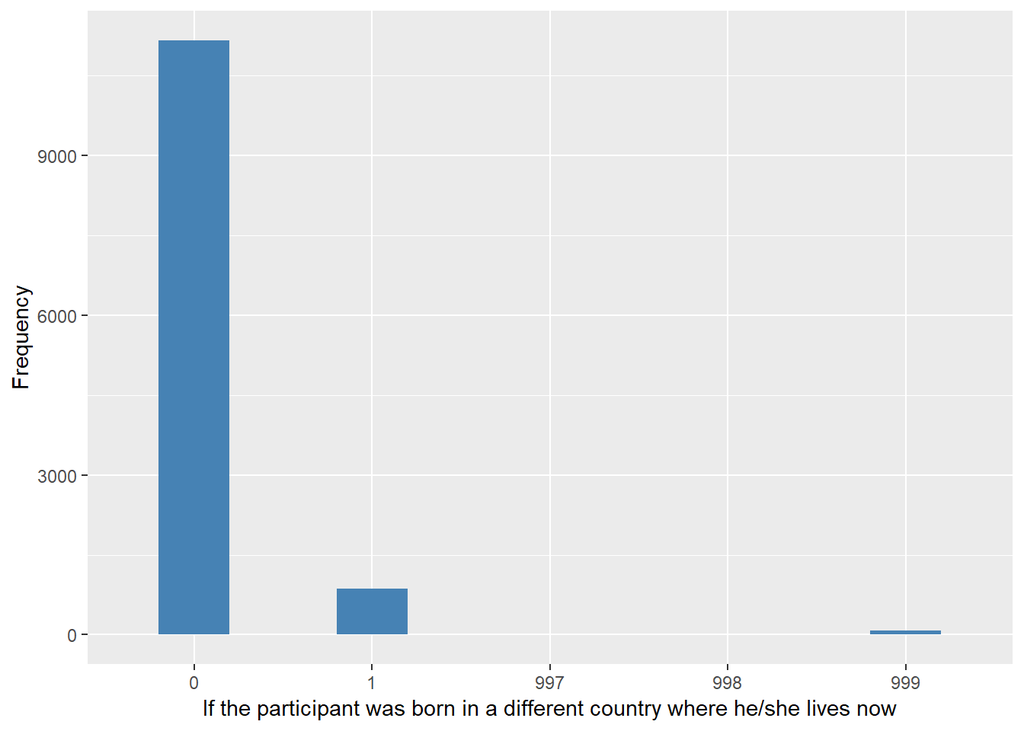

#### 2.1.1.4 Validation

### 2.1.2 Wave 2

#### 2.1.2.1 Study-specific variable description

| **Name** | `fqcbthr` |
| --- | --- |
| **Label** | `Country of birth recoded into UK and non-UK` |
| **Table name** | `wave_2_core_data_v4` |
| **Categories** | `1 = UK` `2 = Elsewhere outside of UK` |
| **Missings** | `-1 = Not applicable` ``-8 = Don't Know` `-9 = Refusal` |
| **Description** |  |

fqcbthr

| Sample size | Missing values |
| --- | --- |
| 9432 | 9312 |

Category

|  | 1 | 2 |
| --- | --- | --- |
| Frequency | 98.00 | 22.00 |
| Percentage | 1.04 | 0.23 |

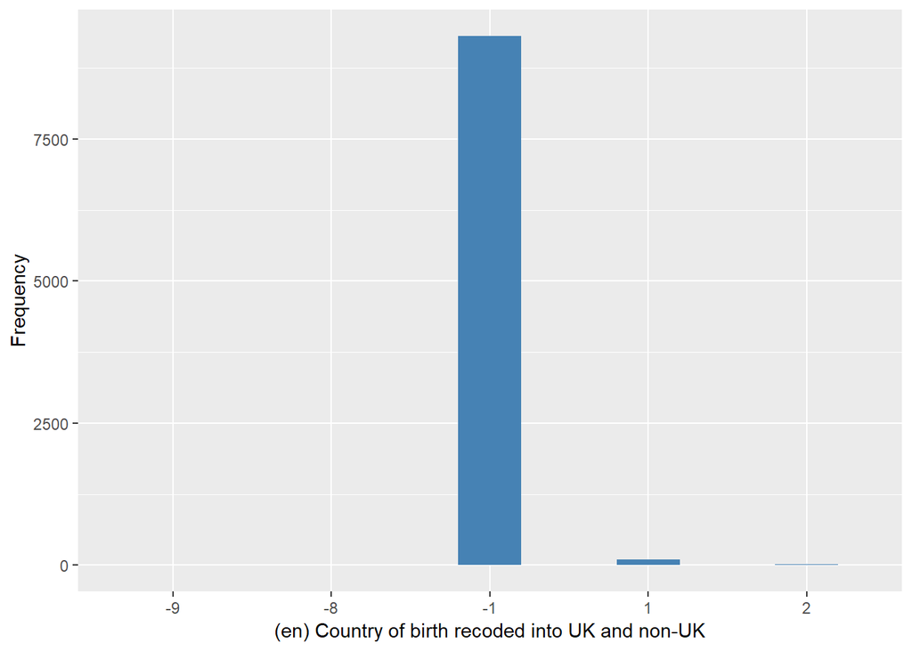

#### 2.1.2.2 Harmonisation algorithm

To compute `migration` from the study-specific variable it has to be recoded `fqcbthr` as follows:

- `1 into 0`
- `2 into 1`
- `-9 into 997`
- `-8 into 998`
- `-1 into 996`

The missing values are going to be completed with the information of the last wave.

**R script:**

```r
ELSA_ds_w2 <- tibble(id = ELSA_w2$id)
ELSA_ds_w2$migration <- car::recode(ELSA_w2$fqcbthr, "1 = 0; 2 = 1; -1 = 996; -9 = 997; -8 = 998 ")
ELSA_ds_w2$migration[(ELSA_ds_w2$migration %in% c(996, 997, 998, 999))] <- ELSA_w2$migration[(ELSA_ds_w2$migration %in%
    c(996, 997, 998, 999))]
```

#### 2.1.2.3 Statistical description of the new harmonised variable

If the participant was born in a different country where he/she lives now

| Sample size | Missing values |
| --- | --- |
| 9432 | 27 |

Category

|  | 0 | 1 |
| --- | --- | --- |
| Frequency | 8811.00 | 594.0 |
| Percentage | 93.42 | 6.3 |

Type of missing

|  | 991 | 992 | 993 | 994 | 995 | 996 | 997 | 998 | 999 | NA |
| --- | --- | --- | --- | --- | --- | --- | --- | --- | --- | --- |
| Frequency | 0 | 0 | 0 | 0 | 0 | 0 | 1.00 | 2.00 | 2.00 | 22.00 |
| Percentage | 0 | 0 | 0 | 0 | 0 | 0 | 0.01 | 0.02 | 0.02 | 0.23 |

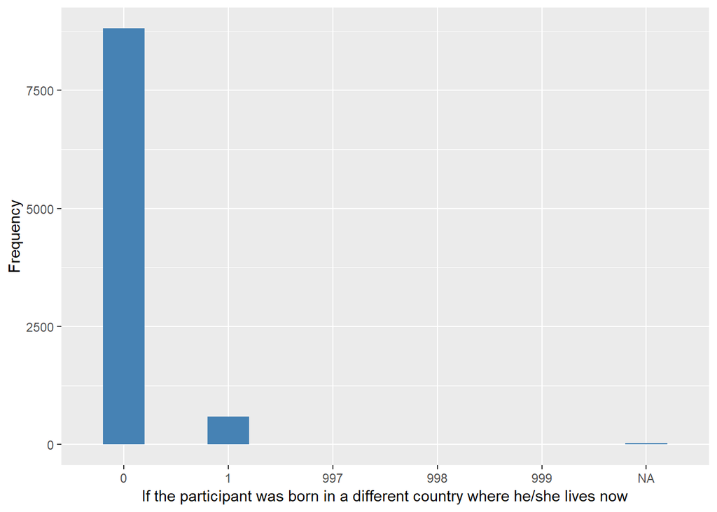

#### 2.1.2.4 Validation

### 2.1.3 Wave 3

#### 2.1.3.1 Study-specific variable description

| **Name** | `fqcbthr` |
| --- | --- |
| **Label** | `Country of birth recoded into UK and non-UK` |
| **Table name** | `wave_3_elsa_data_v4` |
| **Categories** | `1 = UK` `2 = Elsewhere outside of UK` |
| **Missings** | `-1 = Not applicable` ``-8 = Don't Know` `-9 = Refusal` |
| **Description** |  |

fqcbthr

| Sample size | Missing values |
| --- | --- |
| 9771 | 8059 |

Category

|  | 1 | 2 |
| --- | --- | --- |
| Frequency | 1468.00 | 244.0 |
| Percentage | 15.02 | 2.5 |

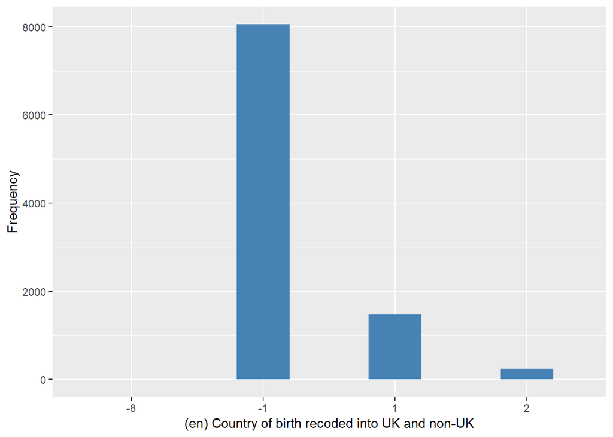

#### 2.1.3.2 Harmonisation algorithm

To compute `migration` from the study-specific variable it has to be recoded `fqcbthr` as follows:

- `1 into 0`
- `2 into 1`
- `-9 into 997`
- `-8 into 998`
- `-1 into 996`

The missing values are going to be completed with the information of the last wave.

**R script:**

```r
ELSA_ds_w3 <- tibble(id = ELSA_w3$id)
ELSA_ds_w3$migration <- car::recode(ELSA_w3$fqcbthr, "1 = 0; 2 = 1; -1 = 996; -9 = 997; -8 = 998 ")
ELSA_ds_w3$migration[(ELSA_ds_w3$migration %in% c(996, 997, 998, 999))] <- ELSA_w3$migration[(ELSA_ds_w3$migration %in%
    c(996, 997, 998, 999))]
```

#### 2.1.3.3 Statistical description of the new harmonised variable

If the participant was born in a different country where he/she lives now

| Sample size | Missing values |
| --- | --- |
| 9771 | 397 |

Category

|  | 0 | 1 |
| --- | --- | --- |
| Frequency | 8673.00 | 701.00 |
| Percentage | 88.76 | 7.17 |

Type of missing

|  | 991 | 992 | 993 | 994 | 995 | 996 | 997 | 998 | 999 | NA |
| --- | --- | --- | --- | --- | --- | --- | --- | --- | --- | --- |
| Frequency | 0 | 0 | 0 | 0 | 0 | 0 | 0 | 0 | 0 | 397.00 |
| Percentage | 0 | 0 | 0 | 0 | 0 | 0 | 0 | 0 | 0 | 4.06 |

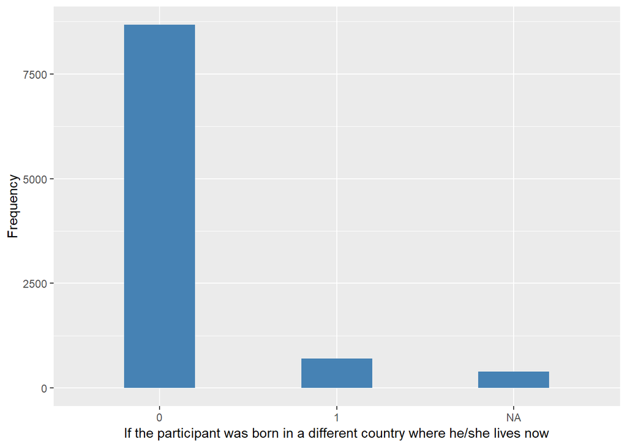

#### 2.1.3.4 Validation

### 2.1.4 Wave 4

| **Name** | `fqcbthr` |
| --- | --- |
| **Label** | `Country of birth recoded into UK and non-UK` |
| **Table name** | `wave_4_elsa_data_v3` |
| **Categories** | `1 = UK` `2 = Elsewhere outside of UK` |
| **Missings** | `-1 = Not applicable` ``-8 = Don't Know` `-9 = Refusal` |
| **Description** |  |

fqcbthr

| Sample size | Missing values |
| --- | --- |
| 11050 | 8282 |

Category

|  | 1 | 2 |
| --- | --- | --- |
| Frequency | 2397.00 | 371.00 |
| Percentage | 21.69 | 3.36 |

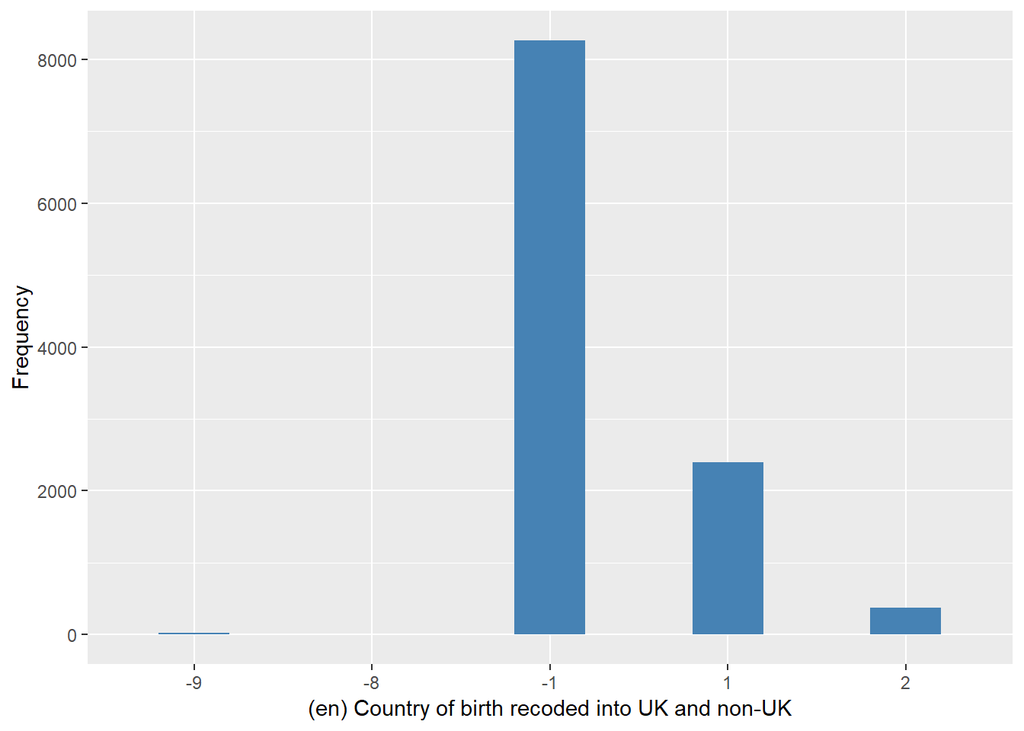

#### 2.1.4.1 Harmonisation algorithm

To compute `migration` from the study-specific variable it has to be recoded `fqcbthr` as follows:

- `1 into 0`
- `2 into 1`
- `-9 into 997`
- `-8 into 998`
- `-1 into 996`

The missing values are going to be completed with the information of the last wave.

**R script:**

```r
ELSA_ds_w4 <- tibble(id = ELSA_w4$id)
ELSA_ds_w4$migration <- car::recode(ELSA_w4$fqcbthr, "1 = 0; 2 = 1; -1 = 996; -9 = 997; -8 = 998 ")
ELSA_ds_w4$migration[(ELSA_ds_w4$migration %in% c(996, 997, 998, 999))] <- ELSA_w4$migration[(ELSA_ds_w4$migration %in%
    c(996, 997, 998, 999))]
```

#### 2.1.4.2 Statistical description of the new harmonised variable

If the participant was born in a different country where he/she lives now

| Sample size | Missing values |
| --- | --- |
| 11050 | 672 |

Category

|  | 0 | 1 |
| --- | --- | --- |
| Frequency | 9468.00 | 910.00 |
| Percentage | 85.68 | 8.24 |

Type of missing

|  | 991 | 992 | 993 | 994 | 995 | 996 | 997 | 998 | 999 | NA |
| --- | --- | --- | --- | --- | --- | --- | --- | --- | --- | --- |
| Frequency | 0 | 0 | 0 | 0 | 0 | 0 | 0 | 0 | 0 | 672.00 |
| Percentage | 0 | 0 | 0 | 0 | 0 | 0 | 0 | 0 | 0 | 6.08 |

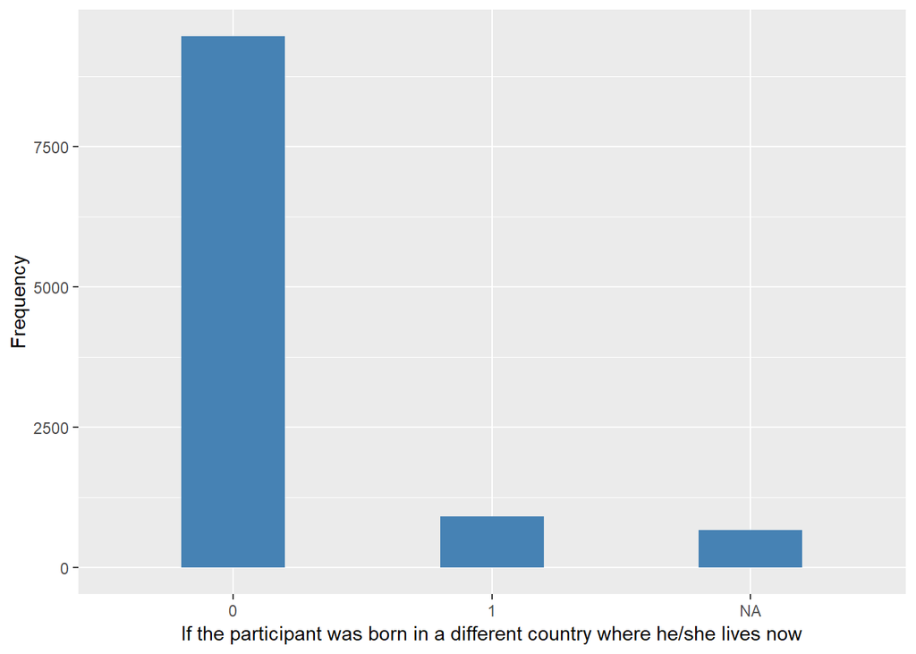

#### 2.1.4.3 Validation

### 2.1.5 Wave 5

#### 2.1.5.1 Study-specific variable description

| **Name** | `fqcbthr` |
| --- | --- |
| **Label** | `Country of birth recoded into UK and non-UK` |
| **Table name** | `wave_5_elsa_data_v4` |
| **Categories** | `1 = UK` `2 = Elsewhere outside of UK` |
| **Missings** | `-1 = Not applicable` ``-8 = Don't Know` `-9 = Refusal` |
| **Description** |  |

fqcbthr

| Sample size | Missing values |
| --- | --- |
| 10274 | 9958 |

Category

|  | 1 | 2 |
| --- | --- | --- |
| Frequency | 272.00 | 44.00 |
| Percentage | 2.65 | 0.43 |

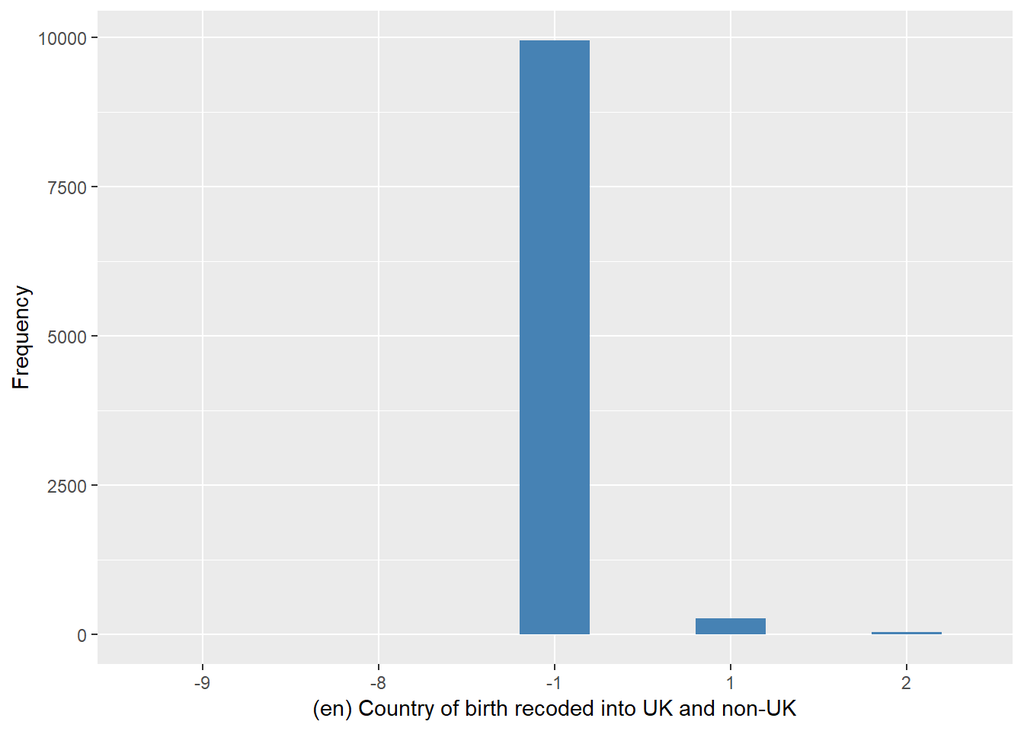

#### 2.1.5.2 Harmonisation algorithm

To compute `migration` from the study-specific variable it has to be recoded `fqcbthr` as follows:

- `1 into 0`
- `2 into 1`
- `-9 into 997`
- `-8 into 998`
- `-1 into 996`

The missing values are going to be completed with the information of the last wave.

**R script:**

```r
ELSA_ds_w5 <- tibble(id = ELSA_w5$id)
ELSA_ds_w5$migration <- car::recode(ELSA_w5$fqcbthr, "1 = 0; 2 = 1; -1 = 996; -9 = 997; -8 = 998 ")
ELSA_ds_w5$migration[(ELSA_ds_w5$migration %in% c(996, 997, 998, 999))] <- ELSA_w5$migration[(ELSA_ds_w5$migration %in%
    c(996, 997, 998, 999))]
```

#### 2.1.5.3 Statistical description of the new harmonised variable

If the participant was born in a different country where he/she lives now

| Sample size | Missing values |
| --- | --- |
| 10274 | 1125 |

Category

|  | 0 | 1 |
| --- | --- | --- |
| Frequency | 8347.00 | 802.00 |
| Percentage | 81.24 | 7.81 |

Type of missing

|  | 991 | 992 | 993 | 994 | 995 | 996 | 997 | 998 | 999 | NA |
| --- | --- | --- | --- | --- | --- | --- | --- | --- | --- | --- |
| Frequency | 0 | 0 | 0 | 0 | 0 | 0 | 0 | 0 | 0 | 1125.00 |
| Percentage | 0 | 0 | 0 | 0 | 0 | 0 | 0 | 0 | 0 | 10.95 |

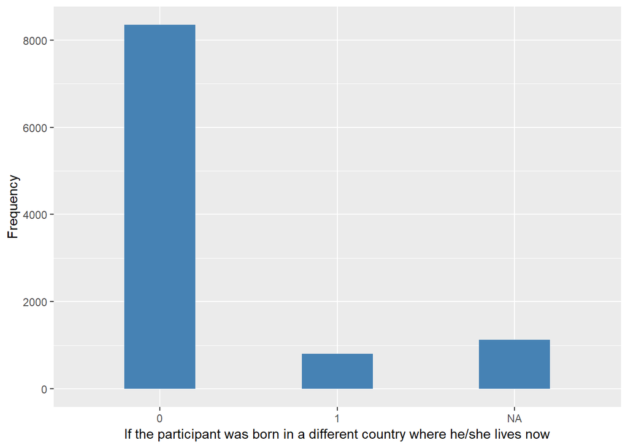

#### 2.1.5.4 Validation

### 2.1.6 Wave 6

#### 2.1.6.1 Study-specific variable description

| **Name** | `Fqcbthr` |
| --- | --- |
| **Label** | `Country of birth recoded into UK and non-UK` |
| **Table name** | `wave_6_elsa_data_v2` |
| **Categories** | `1 = UK` `2 = Elsewhere outside of UK` |
| **Missings** | `-1 = Not applicable` ``-8 = Don't Know` `-9 = Refusal` |
| **Description** |  |

Fqcbthr

| Sample size | Missing values |
| --- | --- |
| 10601 | 9226 |

Category

|  | 1 | 2 |
| --- | --- | --- |
| Frequency | 1194.00 | 181.00 |
| Percentage | 11.26 | 1.71 |

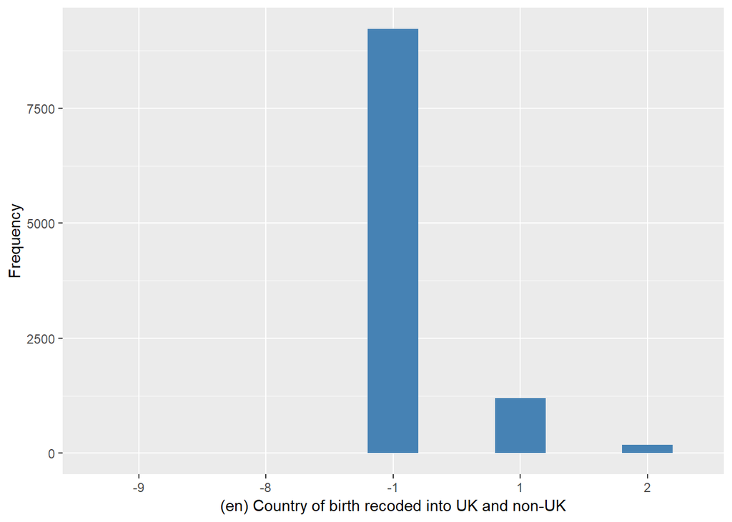

#### 2.1.6.2 Harmonisation algorithm

To compute `migration` from the study-specific variable it has to be recoded `fqcbthr` as follows:

- `1 into 0`
- `2 into 1`
- `-9 into 997`
- `-8 into 998`
- `-1 into 996`

The missing values are going to be completed with the information of the last wave.

**R script:**

```r
ELSA_ds_w6 <- tibble(id = ELSA_w6$id)
ELSA_ds_w6$migration <- car::recode(ELSA_w6$Fqcbthr, "1 = 0; 2 = 1; -1 = 996; -9 = 997; -8 = 998 ")
ELSA_ds_w6$migration[(ELSA_ds_w6$migration %in% c(996, 997, 998, 999))] <- ELSA_w6$migration[(ELSA_ds_w6$migration %in%
    c(996, 997, 998, 999))]
```

#### 2.1.6.3 Statistical description of the new harmonised variable

If the participant was born in a different country where he/she lives now

| Sample size | Missing values |
| --- | --- |
| 10601 | 1183 |

Category

|  | 0 | 1 |
| --- | --- | --- |
| Frequency | 8535.00 | 883.00 |
| Percentage | 80.51 | 8.33 |

Type of missing

|  | 991 | 992 | 993 | 994 | 995 | 996 | 997 | 998 | 999 | NA |
| --- | --- | --- | --- | --- | --- | --- | --- | --- | --- | --- |
| Frequency | 0 | 0 | 0 | 0 | 0 | 0 | 0 | 0 | 0 | 1183.00 |
| Percentage | 0 | 0 | 0 | 0 | 0 | 0 | 0 | 0 | 0 | 11.16 |

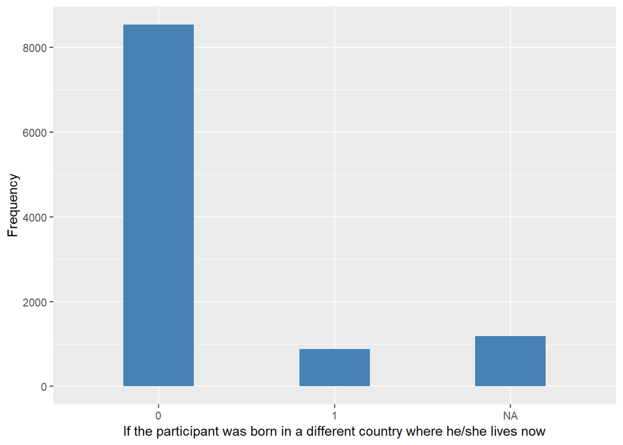

#### 2.1.6.4 Validation

### 2.1.7 Wave 7

#### 2.1.7.1 Study-specific variable description

[output not shown]

Fqcbthr

| Sample size | Missing values |
| --- | --- |
| 9666 | 9065 |

Category

|  | 1 | 2 |
| --- | --- | --- |
| Frequency | 531.00 | 70.00 |
| Percentage | 5.49 | 0.72 |

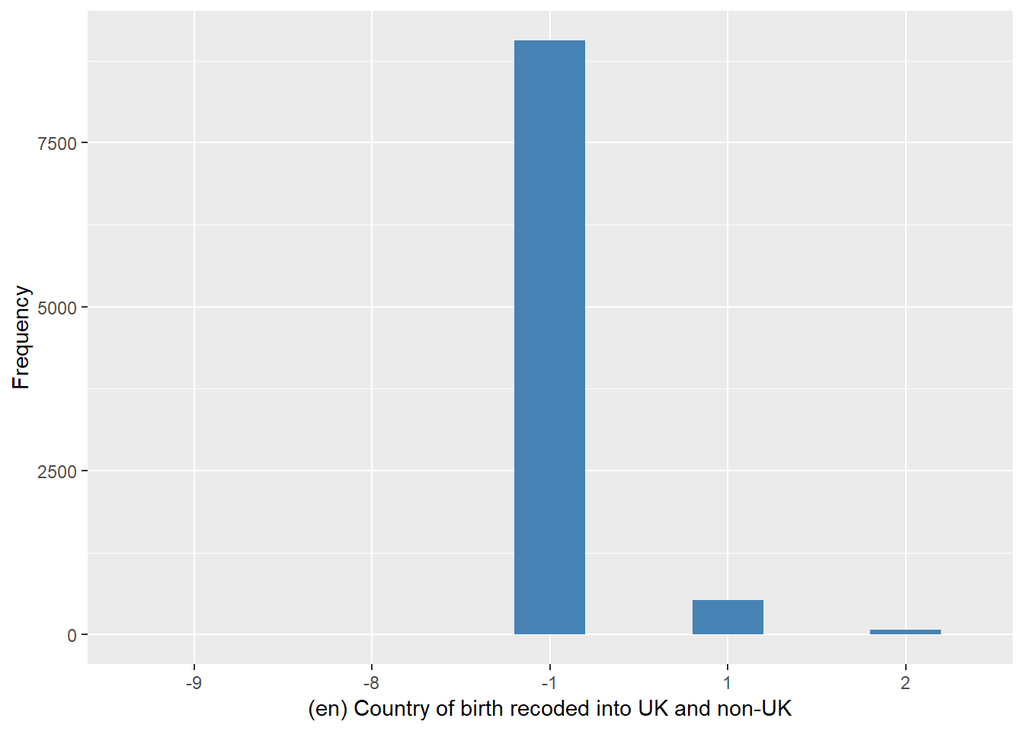

#### 2.1.7.2 Harmonisation algorithm

To compute `migration` from the study-specific variable it has to be recoded `fqcbthr` as follows:

- `1 into 0`
- `2 into 1`
- `-9 into 997`
- `-8 into 998`
- `-1 into 996`

The missing values are going to be completed with the information of the last wave.

**R script:**

```r
ELSA_ds_w7 <- tibble(id = ELSA_w7$id)
ELSA_ds_w7$migration <- car::recode(ELSA_w7$Fqcbthr, "1 = 0; 2 = 1; -1 = 996; -9 = 997; -8 = 998 ")
ELSA_ds_w7$migration[(ELSA_ds_w7$migration %in% c(996, 997, 998, 999))] <- ELSA_w7$migration[(ELSA_ds_w7$migration %in%
    c(996, 997, 998, 999))]
```

#### 2.1.7.3 Statistical description of the new harmonised variable

If the participant was born in a different country where he/she lives now

| Sample size | Missing values |
| --- | --- |
| 9666 | 1093 |

Category

|  | 0 | 1 |
| --- | --- | --- |
| Frequency | 7772.00 | 801.00 |
| Percentage | 80.41 | 8.29 |

Type of missing

|  | 991 | 992 | 993 | 994 | 995 | 996 | 997 | 998 | 999 | NA |
| --- | --- | --- | --- | --- | --- | --- | --- | --- | --- | --- |
| Frequency | 0 | 0 | 0 | 0 | 0 | 0 | 0 | 0 | 0 | 1093.00 |
| Percentage | 0 | 0 | 0 | 0 | 0 | 0 | 0 | 0 | 0 | 11.31 |

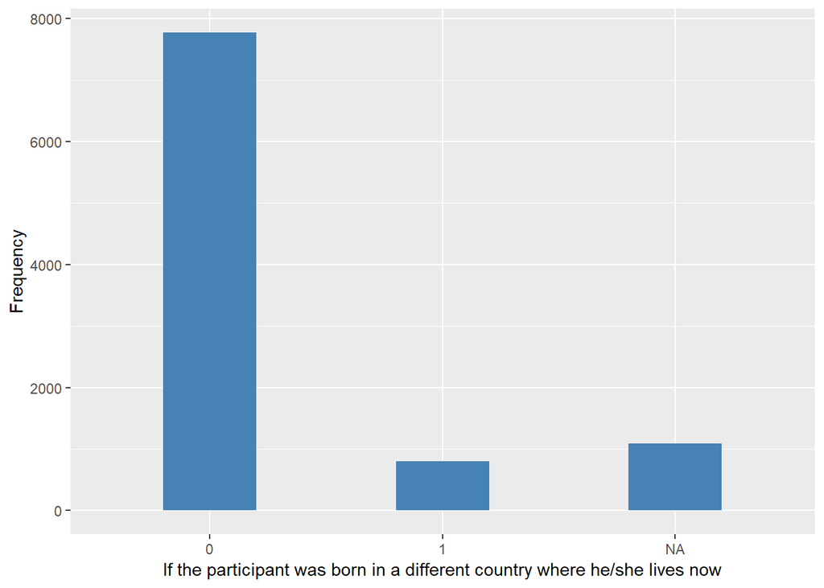

#### 2.1.7.4 Validation

## 2.2 Summary of descriptive statistics of the harmonised variable accross populations and waves

Two tables are generated:

1. Percentages of categories in each harmonised variable.
2. Frequencies and percentages of individuals with different trajectories.

If the participant was born in a different country where he/she lives now

| val | label | W1 | W2 | W3 | W4 | W5 | W6 | W7 |
| --- | --- | --- | --- | --- | --- | --- | --- | --- |
| 0 | no migrant | 92.21 | 93.42 | 88.76 | 85.68 | 81.24 | 80.51 | 80.41 |
| 1 | migrant | 7.12 | 6.3 | 7.17 | 8.24 | 7.81 | 8.33 | 8.29 |
| 991 | CAPI interviewer error | 0 | 0 | 0 | 0 | 0 | 0 | 0 |
| 992 | Impute | 0 | 0 | 0 | 0 | 0 | 0 | 0 |
| 993 | Disable to measure | 0 | 0 | 0 | 0 | 0 | 0 | 0 |
| 994 | Not attempt not done | 0 | 0 | 0 | 0 | 0 | 0 | 0 |
| 995 | Does not answer | 0 | 0 | 0 | 0 | 0 | 0 | 0 |
| 996 | Not applicable | 0 | 0 | 0 | 0 | 0 | 0 | 0 |
| 997 | Refuse | 0.02 | 0.01 | 0 | 0 | 0 | 0 | 0 |
| 998 | Do not know | 0.02 | 0.02 | 0 | 0 | 0 | 0 | 0 |
| 999 | Missing | 0.64 | 0.02 | 0 | 0 | 0 | 0 | 0 |
| NA | NA | 0 | 0.23 | 4.06 | 6.08 | 10.95 | 11.16 | 11.31 |
| n | sample size | 12099 | 9432 | 9771 | 11050 | 10274 | 10601 | 9666 |

| val | frq | raw.prc |
| --- | --- | --- |
| 0000000 | 4111 | 22.23 |
| 0000001 | 2 | 0.01 |
| 000000NA | 639 | 3.46 |
| 00000NANA | 550 | 2.97 |
| 0000111 | 2 | 0.01 |
| 000011NA | 1 | 0.01 |
| 00001NANA | 1 | 0.01 |
| 0000NA0NA | 3 | 0.02 |
| 0000NANANA | 684 | 3.70 |
| 0001111 | 3 | 0.02 |
| 000NA00NA | 1 | 0.01 |
| 000NANA00 | 3 | 0.02 |
| 000NANA0NA | 1 | 0.01 |
| 000NANANA0 | 3 | 0.02 |
| 000NANANA1 | 1 | 0.01 |
| 000NANANANA | 1135 | 6.14 |
| 00NA0000 | 2 | 0.01 |
| 00NA000NA | 1 | 0.01 |
| 00NA0NANANA | 2 | 0.01 |
| 00NA1111 | 1 | 0.01 |
| 00NANA000 | 3 | 0.02 |
| 00NANA0NANA | 3 | 0.02 |
| 00NANANA00 | 3 | 0.02 |
| 00NANANA0NA | 2 | 0.01 |
| 00NANANANA0 | 4 | 0.02 |
| 00NANANANANA | 1552 | 8.39 |
| 0NANA0000 | 7 | 0.04 |
| 0NANA000NA | 1 | 0.01 |
| 0NANA00NANA | 2 | 0.01 |
| 0NANA0NANANA | 8 | 0.04 |

[output cut: 72 more lines]

# 3 Quality estimation